# python_notebook

## Variable

```python
name ="VaibhaV"
```

```python
print(name)
```

```
VaibhaV
```

### Object Types / Data Types

- Number : 1234, 3.1415, 3+4j, 0b111, Decimal(), Fraction()
- String : 'spam', "Bob's", b'a\x01c', u'sp\xc4m'
- List : [1, [2, 'three'], 4.5], list(range(10))
- Tuple : (1, 'spam', 4, 'U'), tuple('spam'), namedtuple
- Dictionary : {'food': 'spam', 'taste': 'yum'}, dict(hours=10)
- Set : set('abc'), {'a', 'b', 'c'}
- File : open('eggs.txt'), open(r'C:\ham.bin', 'wb')
- Boolean : True, False
- None : None
- Funtions, modules, classes
- Advance: Decorators, Generators, Iterators, MetaProgramming

## Data type

- int
- float
- Boolean
- String

```python
num1= 1
print(type(num1))
num2= 2.303
print(type(num2))
num3= True
print(type(num3))
num4= "VaibhaV"
print(type(num4))
```

```
<class 'int'>
<class 'float'>
<class 'bool'>
<class 'str'>
```

## Arithmatic Operator +, -, *, /

```python
num1, num2 = 36, 7
```

```python
num1 + num2
```

```
43
```

```python
num1 - num2
```

```
29
```

```python
num1 * num2
```

```
252
```

```python
num1 / num2
```

```
5.142857142857143
```

```python
num1 // num2
```

```
5
```

## Relational Operator <, >, ==, !=

```python
num1 > num2
```

```
True
```

```python
num1 < num2
```

```
False
```

```python
num1 == num2
```

```
False
```

```python
num1 != num2
```

```
True
```

## Logical Operator & |

```python
log1 = True
log2 = False
```

```python
log1 & log2
```

```
False
```

```python
log1 & log1
```

```
True
```

```python
log1 | log1
```

```
True
```

## Python Tokens

Smallest meaningfull componet in program

- Keywords : Special reserved words like For If Yield
- Identifiers: Names used for variables, functions or objects
- Literals : Costants in python
  - num = "Test" : here "num" is Identifier and "Test" is literal
- Operators

## String:

```python
str1 = "I love Pizza"
str1.find("Piz")
```

```
7
```

```python
fruits ="Mango, Banana, Apple"
fruits.split(", ")
```

```
['Mango', 'Banana', 'Apple']
```

## List

In Python, a list is a built-in data structure that allows you to store an ordered collection of items. These items can be of any data type, including integers, strings, floats, or even other lists. Lists are mutable, meaning you can change their content without changing their identity.

Here is a basic definition and example of a list in Python:

Definition:A list is defined by placing a comma-separated sequence of items within square brackets [].

Key Characteristics:

- Ordered: The items have a defined order, and that order will not change unless you explicitly modify the list.
- Mutable: You can change, add, or remove items after the list has been created.
- Heterogeneous: A list can contain items of different data types.

Common Operations:

- Accessing Elements: Use indexing to access individual elements.
- Slicing: Use slicing to access a range of elements.
- Appending: Use append() to add an element to the end of the list.
- Inserting: Use insert() to add an element at a specific position.
- Removing: Use remove() to remove a specific element.
- Popping: Use pop() to remove an element at a specific position and return it.
- Length: Use len() to get the number of elements in the list.

```python
l1 = [1, "a", 2, True]
```

```python
l1[0]=100
l1
```

```
[100, 'a', 2, True]
```

```python
l1.append("VaibhaV")
l1
```

```
[100, 'a', 2, True, 'VaibhaV']
```

```python
l1.pop()
```

```
'VaibhaV'
```

```python
l1
```

```
[100, 'a', 2, True]
```

```python
l1.reverse()
l1
```

```
[True, 2, 'a', 100]
```

```python
l1.insert(1, "Test")
l1
```

```
[True, 'Test', 2, 'a', 100]
```

```python
l1.sort()
l1
```

```
---------------------------------------------------------------------------
TypeError                                 Traceback (most recent call last)
Cell In[28], line 1
----> 1 l1.sort()
      2 l1

TypeError: '<' not supported between instances of 'str' and 'bool'
```

```python
l2 = ['Mango', 'Banana', 'Apple']
l2.sort()
l2
```

```
['Apple', 'Banana', 'Mango']
```

```python
l1 = ["a", "b", "c"]
l2 = [1, 2, 3]
l1+ l2
```

```
['a', 'b', 'c', 1, 2, 3]
```

```python
l1 = [1, "b", True]
l1 * 3
```

```
[1, 'b', True, 1, 'b', True, 1, 'b', True]
```

## Tuple

- Tuple are ordered collection of elements enclosed within ()
- Tuples are immutable, once created we can not update or change values of tuple

```python
tup1 = (1, "b", True)
tup1
```

```
(1, 'b', True)
```

```python
type(tup1)
```

```
tuple
```

```python
tup2 = tup1 *3
tup2
```

```
(1, 'b', True, 1, 'b', True, 1, 'b', True)
```

```python
tup2[1:6]
```

```
('b', True, 1, 'b', True)
```

```python
tup2[::2]
```

```
(1, True, 'b', 1, True)
```

```python
tup2[2]="Test"
```

```
---------------------------------------------------------------------------
TypeError                                 Traceback (most recent call last)
Cell In[36], line 1
----> 1 tup2[2]="Test"

TypeError: 'tuple' object does not support item assignment
```

```python
tup1 = ("a", "b", "c")
tup2 = (1, 2, 3)
tup1 + tup2
```

```
('a', 'b', 'c', 1, 2, 3)
```

## Dictionary

- Dictionary is an unordered collection of key-value pairs enclosed with {}
- Dictionary is mutable

```python
fruit = {"Mango": 10, 'Banana': 20, 'Apple':30}
```

```python
fruit.keys()
```

```
dict_keys(['Mango', 'Banana', 'Apple'])
```

```python
fruit.values()
```

```
dict_values([10, 20, 30])
```

```python
fruit["Guava"]=40
fruit
```

```
{'Mango': 10, 'Banana': 20, 'Apple': 30, 'Guava': 40}
```

```python
fruit
```

```
{'Mango': 10, 'Banana': 20, 'Apple': 30, 'Guava': 40}
```

```python
f1 = {'Mango': 10, 'Banana': 20}
f2 = {'Apple': 30, 'Guava': 40}
```

```python
f1.update(f2)
f1
```

```
{'Mango': 10, 'Banana': 20, 'Apple': 30, 'Guava': 40}
```

```python
f1.pop("Guava")
```

```
40
```

```python
f1
```

```
{'Mango': 10, 'Banana': 20, 'Apple': 30}
```

## Set

- Set ia a unordered and unindexed collection of elements enclosed with {}
- Duplicates are not allowed in Set

```python
# Try duplicates with set
s1 = {"c", "a", "b", 1, 2, 3, "a", "b", 1, 2}
s1
```

```
{1, 2, 3, 'a', 'b', 'c'}
```

```python
s1.add("Test")
s1
```

```
{1, 2, 3, 'Test', 'a', 'b', 'c'}
```

```python
s1.remove("b")
s1
```

```
{1, 2, 3, 'Test', 'a', 'c'}
```

```python
s1 = {'Mango', 'Banana', 'Apple', 1, 2, 'a'}
s2 = {'a', 'b', 'c', 1, 2}
s1.union(s2)
```

```
{1, 2, 'Apple', 'Banana', 'Mango', 'a', 'b', 'c'}
```

```python
s1
```

```
{1, 2, 'Apple', 'Banana', 'Mango', 'a'}
```

```python
s2
```

```
{1, 2, 'a', 'b', 'c'}
```

```python
s1.intersection(s2)
```

```
{1, 2, 'a'}
```

```python
s1.update(s2)
s1
```

```
{1, 2, 'Apple', 'Banana', 'Mango', 'a', 'b', 'c'}
```

## Decision making / Conditions

```python
a, b= 10, 20
```

```python
if a>b:
    print("A is greater than B")
else:
    print("B is greater than A")
```

```
B is greater than A
```

```python
result= "A is greater than B" if a>b else "B is greater than A"
result
```

```
'B is greater than A'
```

```python
tup= ("a", "b", "c")
```

```python
if "z" in tup:
    print("z is in tup")
else:
    print("z is not in tup")
```

```
z is not in tup
```

```python
"z is in tup" if "z" in tup else "z is not in tup"
```

```
'z is not in tup'
```

## Looping Statement

To repeat task multiple times

```python
fruit = ['Mango', 'Banana', 'Apple']
for frt in fruit:
    print(frt)
```

```
Mango
Banana
Apple
```

```python
i= 1
while i<=10:
    print(i)
    i+=1
```

```
1
2
3
4
5
6
7
8
9
10
```

## Object Oriented Programming

- Class: user defined data type
  - Attributes
  - Methods
- Objects : Specific instance of a class

```python
class Phone:
    def make_call(self):
        print("Making phone call")
    def play_game(self):
        print("Playing game")
    def set_color(self, color):
        self.color = color
    def set_cost(self, cost):
        self.cost = cost
    def show_color(self):
        return self.color
    def show_cost(self):
        return self.cost
```

```python
p1 = Phone()
```

```python
p1.make_call()
```

```
Making phone call
```

```python
p1.play_game()
```

```
Playing game
```

```python
p1.set_color("Red")
```

```python
p1.set_cost(1000)
```

```python
p1.show_color()
```

```
'Red'
```

```python
p1.show_cost()
```

```
1000
```

### Constructor

```python
class Phone:
    def __init__(self, color, cost):
        self.color = color
        self.cost = cost
    def make_call(self):
        print("Making phone call")
    def play_game(self):
        print("Playing game")
```

```python
p1 = Phone("Red", 2000)
```

```python
p1.color
```

```
'Red'
```

## Inheritance

With inheritance one class can derive the properties of another class

```python
class Vehicle:
    def __init__(self, mileage, cost):
        self.mileage = mileage
        self.cost = cost

    def vehicle_details(self):
        print(f"Vehicle has {self.mileage} mileage and it cost ${self.cost}")
```

```python
v1 = Vehicle(27, 15000)
v1.vehicle_details()
```

```
Vehicle has 27 mileage and it cost $15000
```

```python
class Car(Vehicle):
    def show_car(self):
        print("I am Car")
```

```python
c1 = Car(200, 15000)
```

```python
c1.show_car()
```

```
I am Car
```

```python
c1.vehicle_details()
```

```
Vehicle has 200 mileage and it cost $15000
```

```python
class Car(Vehicle):
    def __init__(self, mileage, cost, hp ):
        super().__init__(mileage, cost)
        self.hp = hp
    def show_car(self):
        print(f"I am car with mileage: {self.mileage}, cost: {self.cost}, power: {self.hp} ")
```

```python
c1= Car(100, 15000, 2000)
```

```python
c1.show_car()
```

```
I am car with mileage: 100, cost: 15000, power: 2000
```

```python
c1.vehicle_details()
```

```
Vehicle has 100 mileage and it cost $15000
```

## Multiple Inheretance

Child inherite more than one parent class

```python
class Parent1:
    def assign_string_1(self, name):
        self.name1 = name
    def show_string_1(self):
        return self.name1

class Parent2:
    def assign_string_2(self, name):
        self.name2 = name
    def show_string_2(self):
        return self.name2

class Child(Parent1, Parent2):
    def assign_string_3(self, name):
        self.name3 = name
    def show_string_3(self):
        return self.name3
```

```python
c1 = Child()
c1.assign_string_1("One")
c1.assign_string_2("Two")
c1.assign_string_3("Three")
```

```python
print(c1.show_string_1())
print(c1.show_string_2())
print(c1.show_string_3())
```

```
One
Two
Three
```

## Multi Level Inheritance

-We have Parent, Child, grand-child

```python
class Parent1:
    def assign_name(self, name):
        self.name = name
    def show_name(self):
        return self.name

class Child(Parent1):
    def assign_age(self, age):
        self.age = age
    def show_age(self):
        return self.age

class GrandChild(Child):
    def assign_gender(self, gender):
        self.gender = gender
    def show_gender(self):
        return self.gender
```

```python
gc = GrandChild()
```

```python
gc.assign_name("Test")
```

```python
gc.assign_age(21)
```

```python
gc.assign_gender("Male")
```

```python
print(f"{gc.show_name()} is a {gc.show_gender()} aged {gc.show_age()}")
```

```
Test is a Male aged 21
```

## File Handling

- Open mode : Open text file for reading, writing and doing some other stuff
- Read mode : To read the text which is already stored in your text file
- Write mode : To write your text in .txt file

```python
file = open('processed_data/test.txt', 'w')

try:
    file.write('Chai aur code line 1')
finally:
    file.close()
```

```python
file = open('processed_data/test.txt', 'a')

try:
    file.write('\nChai aur code line 2')
finally:
    file.close()
```

```python
file = open('processed_data/test.txt', 'r')
data_read = file.read()
print(data_read)
total_count = len(data_read)
print(total_count)
```

```
Chai aur code line 1
Chai aur code line 2
41
```

## Readline functions

```python
f = open('processed_data/test.txt', 'w')
f.write("I am learning file handling\n")
f.write("Topic is file handling, read and write")
```

```
38
```

```python
f = open('processed_data/test.txt', 'r')
```

```python
print(f.readline())
```

```
I am learning file handling
```

```python
# Using 'with' to handle file operations
file_path = 'processed_data/example.txt'

# Writing to a file
with open(file_path, 'w') as file:
    file.write("Hello, this is a file handling example using 'with'.\n")
    file.write("This automatically manages the file resource.\n")

# Reading from a file
with open(file_path, 'r') as file:
    content = file.read()

# Output the content
print("File Content:\n")
print(content)
```

```
File Content:

Hello, this is a file handling example using 'with'.
This automatically manages the file resource.
```

```python
print(f.readline())
```

```
Topic is file handling, read and write
```

```python
print(f.readline())
```

## Try Except

```python
a =input("Enter the number 1 : ")
b =input("Enter the number 2 : ")

try:
    c= int(a) + b
    print(c)
except Exception as e:
    print(e)
```

```
unsupported operand type(s) for +: 'int' and 'str'
```

```python
try:
    c= int(a) + b
    print(c)
except:
    print("Error in try block")
```

```
Error in try block
```

## Try with else clause

Else clause is used with the try clause when you want to execute the set of instructions in the absence of exceptions in your code

```python
a =input("Enter the number 1 : ")
b =input("Enter the number 2 : ")

try:
    c= int(a) + int(b)
    print(c)
except Exception as e:
    print(e)
else:
    print("All inputs are good, Else clause got executed!!")
```

```
3
All inputs are good, Else clause got executed!!
```

## Try Finally keyword

Finally is a keyword which surely executes after the execution of the try except block of statement

```python
a =input("Enter the number 1 : ")
b =input("Enter the number 2 : ")

try:
    c= int(a) + b
    print(c)
except:
    print("Error in try block")
finally:
    print("Finally runs post try except")
```

```
Error in try block
Finally runs post try except
```

```python
a = 1
b = 'w'

try:
    c= int(a) + int(b)
    print(c)
except Exception as e:
    print(e)
else:
    print("All inputs are good, Else clause got executed!!")
finally:
    print("Finally runs post try except")
```

```
invalid literal for int() with base 10: 'w'
Finally runs post try except
```

# Data Structures And Algorithms

- Arrays
- Stack
- Queue
- Linked List
- Linear Search
- Binary Search
- Insersion Sort
- Quick Sort
- Merge Sort

## Arrays:

- Linear Data structure
- Continous Memory Locations
- Access elements randomly
- Homogeneous elements i.e. similar elements

### Applications

- Storing Information - linear fashion
- Suitable for applications that require frequent searching

### 1-Dimentional Array

- 1D can be related to a row
- Elements are stored one after another
- Only one subscript or index is used

### Declaration and Initialization

- Array declaration:
  - Datatype varname [size]
- Can also do declaration and initialization at once:
  - Datatype varname [] = {ele1, ele2, ele3, ele4};

### 2-Dimentional Array

- 2D can be related to a table or matrix
- Elements are stored one after another i.e. one 1D array inside another.
- Two subscripts or indices are used, one row and one column.
- Dimensions depends upon the number of subscripts used.

```python
# 1D array
print("How many elements to store inside the array", end="")
num = input()
arr = []
print("\nEnter", num, "Element:", end="")
num = int(num)
for i in range(num):
    element = input()
    arr.append(element)
print("\nThe array elements are")
for i in range(num):
    print(arr[i], end=" ")
```

```
How many elements to store inside the array
Enter 2 Element:
The array elements are
3 4
```

```python
r_num = int(input("Input number of rows: "))
c_num = int(input("Input number of columns: "))
twoD_arr = [[0 for col in range(c_num)] for row in range(r_num)]
print(twoD_arr)
```

```
[[0, 0, 0], [0, 0, 0]]
```

```python
# 2D Array
r_num = int(input("Input number of rows: "))
c_num = int(input("Input number of columns: "))
twoD_arr = [[0 for col in range(c_num)] for row in range(r_num)]
# print("Enter the elements of the matrix: ")
# for i in range(r_num):
#     for j in range(c_num):
#         twoD_arr[i][j] = int(input())
print("The matrix is: ")
for i in range(r_num):
    for j in range(c_num):
        print(twoD_arr[i][j], i*j)
        twoD_arr[i][j]= i*j
print(twoD_arr)
```

```
The matrix is:
0 0
0 0
0 0
0 0
0 1
0 2
[[0, 0, 0], [0, 1, 2]]
```

```python
# Array with user defined value
print(end="Enter the size of Array: ")
tot = int(input())
arr = []
print(end="Enter " +str(tot)+ " Elements: ")
for i in range(tot):
    arr.append(input())
print("\nThe new array is: ")
for i in range(tot):
    print(end=arr[i]+" ")
print(end="\nEnter the value to Delete: ")
val = input()
if val in arr:
    arr.remove(val)
    print("\nThe new array is: ")
    for i in range(tot-1):
        print(end=arr[i]+" ")
else:
    print("\nElement doent exist in the List!")
```

```
Enter the size of Array: Enter 3 Elements:
The new array is:
2 4 6
Enter the value to Delete:
The new array is:
2 6
```

```python
# Sort elements in an array
arr = [10, 22, 38, 27, 11]
temp = 0;

#Displaying elements of original array
print("Elements of original array: ");
for i in range(0, len(arr)):
    print(arr[i], end=" ");

#Sort the array in ascending order
for i in range(0, len(arr)):
    for j in range(i + 1, len(arr)):
        if(arr[i] > arr[j]):
            temp = arr[i];
            arr[i] = arr[j];
            arr[j] = temp;
print();
#Displaying elements of the array after sorting
print("\nElements of array sorted in ascending order: ")
for i in range(0, len(arr)):
    print(arr[i], end=" ");
```

```
Elements of original array:
10 22 38 27 11

Elements of array sorted in ascending order:
10 11 22 27 38
```

```python
# Search element in an array
import array
arr = array.array('i', [1, 2, 3, 1, 2, 5])
print("Elements of original array: ")
for i in range(0, 6):
    print(arr[i], end=" ");
print("\r");
print("The index of first occurance of 2 is: ", end="")
print(arr.index(2))
print("The index of first occurance of 1 is: ", end="")
print(arr.index(1))
```

```
Elements of original array:
1 2 3 1 2 5
The index of first occurance of 2 is: 1
The index of first occurance of 1 is: 0
```

### Advantages of an array

- Random access elements
- Easy sorting and iteration
- Replacement of multiple variables

### Disadvantage of an array

- Size is fixed
- Difficult to insert and delete
- If capacity is more and occupancy less most of the array gets wasted
- Needs continous memory

# Stack

- Linear data structure
- It follows Last In First Out(LIFO) order
- Insertion and removal of the element has done at one end
- Push is used for inserting an element in a stack
- Pop is used to removal an element in a stack

### Functions

- push(x) - it is used to insert the element 'x' at the end of a stack.
- pop() - it is used to remove the topmost/last element of a stack.
- size() - gives the size/length of a stack.
- top() - give reference of last element present in stack
- empty() - return true for an empty stack

### Implementation of Stack

Several ways to implement stack in python

- list
- collections.deque
- queue.LifoQueue

### Implementation of stack using list

List in python can be used as stack

- append() - it is used to insert the element
- pop() - it is used to remove the last element

Logic-

stack = []

stack.append("abc")

print(stack.pop())

```python
# Implementation of stack using list
stack= []
stack.append("Welcome")
stack.append("to")
stack.append("great learning")
print(stack)
print(stack.pop())
print(stack)
```

```
['Welcome', 'to', 'great learning']
great learning
['Welcome', 'to']
```

### Implementation of stack using deque

- STACK in python are created by the collection module which provides deque class.
- Append and pop operations are faster in deque as compared to list

Logic:

from collectios import deque

stack = deque()

stack.append("abc")

print(stack.pop())

```python
### Implementation of stack using deque
from collections import deque
stack = deque()
stack.append("Welcome")
stack.append("to")
stack.append("great learning")
print(stack)
print(stack.pop())
print(stack)
```

```
deque(['Welcome', 'to', 'great learning'])
great learning
deque(['Welcome', 'to'])
```

### Implementation of stack using queue

- Queue module contains the LIFO queue
- It is having some additional functions and works same as stack
- Put function is used to insert the data in queue
- Get function is used to remove the element

### Functions available in queue model

- get() - it is used to remove the element from queue
- maxsize() - Used to put the maximum number of items allowed in queue
- empty() - It return true when queue is empty else false
- full() - When queue is full returns True
- put(x) - It is used to insert x in queue
- qsize() - Gives size of a queue

Logic:

from queue import LifoQueue

stack = Lifoqueue()

```python
# Implementation of stack using queue
from queue import LifoQueue
stack = LifoQueue(maxsize=3)
stack.put("Welcome")
stack.put("to")
stack.put("great learning")
print(stack)
print(stack.qsize())
print(stack.full())
print(stack.get())
print(stack.qsize())
print(stack)
```

```
<queue.LifoQueue object at 0x119c51090>
3
True
great learning
2
<queue.LifoQueue object at 0x119c51090>
```

## What is Queue

- Linear data structure
- Follows FIFO: First in first out
- Insertion can take place from the rear end
- Deletion can take place from front end
- Queue at ticket counter, bus station
- 4 major operations
  - enqueue(ele) - used to insert element at top
  - dequeue() - removes the top element from queue
  - peekfirst() - to get first element of queue
  - peeklast() - to get last element of queue
- All operation works in constant time i.e. 0(1)

### Applications of Queue

- Scheduling
- Maintaining playlist
- Interrupt handling

## Queue Implementation

- Enqueue
- Dequeue
- Display

```python
# Implementation of stack using queue
class Queue:
    def __init__(self):
        self.queue = []
    def enqueue(self, data):
        self.queue.append(data)
    def dequeue(self):
        if len(self.queue)<1:
            return None
        return self.queue.pop(0)
    def display(self):
        print(self.queue)
    def size(self):
        return len(self.queue)
```

```python
q = Queue()
q.enqueue(1)
q.enqueue(2)
q.enqueue(3)
q.enqueue(4)
q.display()
q.dequeue()
q.display()
```

```
[1, 2, 3, 4]
[2, 3, 4]
```

### Queue Implementation

A program implementation for circular queue:

- Enqueue
- Dequeue

```python
# circular queue
class MyCircularQueue():
    def __init__(self, k):
        self.k = k
        self.queue = [None] * k
        self.head = self.tail = -1

    def enqueue (self, data):
        if((self.tail + 1) % self.k == self.head):
            print("Queue is full")
        elif (self.head == -1):
            self.head = 0
            self.tail = 0
            self.queue[self.tail] = data
        else:
            self.tail = (self.tail + 1) % self.k
            self.queue[self.tail] = data

    def dequeue(self):
        if(self.head == -1):
            print("Queue is empty")
        elif(self.head == self.tail):
            temp = self.queue[self.head]
            self.head = -1
            self.tail = -1
            return temp
        else:
            temp = self.queue[self.head]
            self.head = (self.head + 1) % self.k
            return temp

    def printCQueue(self):
        if(self.head == -1):
            print("No element in circular queue is found")
        elif(self.tail >= self.head):
            for i in range(self.head, self.tail + 1):
                print(self.queue[i], end = " ")
            print()
        else:
            for i in range(self.head, self.k):
                print(self.queue[i], end = " ")
            for i in range(0, self.tail + 1):
                print(self.queue[i], end = " ")
            print()
```

```python
obj = MyCircularQueue(5)
obj.enqueue(12)
obj.enqueue(22)
obj.enqueue(31)
obj.enqueue(44)
obj.enqueue(57)
print("Initial queue values")
obj.printCQueue()

obj.dequeue()
print("After removing an element from the queue")
obj.printCQueue()
```

```
Initial queue values
12 22 31 44 57
After removing an element from the queue
22 31 44 57
```

### Disadvantages of queue

- Manipulation is restricted front and rear
- Not much flexible

## Linked List

It is collection or group of nodes

Each node contains data and reference (pointer) which contains the address of next node.

It is linear data structure

Elements are stored randomly in memory

### Why Linked List

- Linked list is having more efficiency for performing the operations as compared to list
- Elements are stored randomly whereas in list at continuous memory
- Accessing the elements in linked list will be slower as compared to list
- Utilization of memory is higher than the list

### Singly Linked List

- It is traversed only in one direction

### Operations of Singly Linked List

- Insertion
- Deletion
- Traversal

### Pseudo Code

Creating a node in Singly Linked List

Class Node:

```
def __init__(self, data):

    self.data=data;

    self.reference=None;
```

node1= Node(7)

print(node1.data)

print(node1.reference)

Creating a class of singly Linked list

class LinkedList

```
def __init__(self):

    self.head=None;
```

```python
# Creating a node class
class Node:
    def __init__(self, data):
        self.data = data
        self.next = None

n1 = Node(7)
print(n1.data)
print(n1.next)
```

```
7
None
```

```python
# creation of Singly Linked List
class SinglyLinkedList:
    def __init__(self):
        self.head = None

sll = SinglyLinkedList()
print(sll.head)
```

```
None
```

## Searching Algorithms

### Linear Search Algorithm

What is Linear Search

- It helps you to search for an element in a linear data structure.
- It checks each and every element for the element to be searched.
- Since this is done in linear fashion, it is termed as linear search.

```python
# linearSearch(arr, item)
#     for each element in array
#         if element == item
#             return index
#     return -1

def linearSearch(arr, n, x):
    for i in range(0, n):
        if (array[i] == x):
            return i
    return -1

array =[2, 4, 0, 1, 9]
n = len(array)
x = 1
result = linearSearch(array, n, x)
if(result == -1):
    print("Element not found")
else:
    print("Element found at index: ", result)
```

```
Element found at index:  3
```

## Linear search - Time complexity

- Best Time complexity: O(1)
- Average Time complexity: O(n)
- Worst Time complexity: O(n)
- Here all the elements need to be compared in worst case to search for a given element.
- Best case could be the case where the first element matched to the element to be searched

## Linear search - Space complexity

- No auxiliary space is required in linear search implementation.
- Hence space complexity is : O(1)

## What is Binary Search

- Binary search is one of the searching technique
- It is used to search an element in a sorted array
- This searching technique is based on divide and conquer strategy and search space always reduces to half in every iteration
- This is very efficient technique for searching but it needs some order on which partition of the array will occur

```python
## Binary Search - Iterative Algorithm
# binarySearch(arr, size)
#     loop until beg is not equal to end
#         midindex = (beg + end) / 2
#         if arr[midindex] == item
#             return midindex
#         else if item > arr[midindex]
#             beg = midindex + 1
#         else
#             end = midindex - 1
```

```python
## Binary Search - Recursive Algorithm
# binarysearch(arr, beg, end, item)
#     if beg <= end
#         mid = (beg + end) / 2
#         if arr[mid] == item
#             return mid
#         else if item > arr[mid]
#             return binarysearch(arr, mid + 1, end, item)
#         else
#             return binarysearch(arr, beg, mid - 1, item)
#     else
#         return -1
```

```python
# Binary search in Python
def binarySearch(arr, l, r, x):
    while l <= r:
        mid = l + (r - l) // 2
        if arr[mid] == x:
            return mid
        elif arr[mid] < x:
            l = mid + 1
        else:
            r = mid - 1
    return -1
```

```python
array = [3,4,5,6,7,8,9]
x = 4
result = binarySearch(array, 0, len(array)-1, x)
if(result == -1):
    print("Element not found")
else:
    print("Element found at index: ", result)
```

```
Element found at index:  1
```

## Binary Search - Time Complexity O(log n)

- Best time complexity: O(1)
- Average time complexity: O(log n)
- Worst time complexity: O(log n)
- In each iteration, the search space is getting divided by 2. That means that in the current iteration you have to deal with half of the previous iteration array. And above steps continue till beg<end.
- Best case could be the case where the first mid-value get matched to the element to be searched.
- Worst case could be the case where the last mid-value get matched to the element to be searched.

## Binary Search - Space Complexity O(1)

- No auxiliary space is required in binary search implementation.
- Hence space complexity is O(1).

## What is insertion sort

- It is one of the easiest and brute force sorting algorithms
- Insertion sort is used to sort elements in either ascending or descending order
- In insersion sort, we maintain a sorted part and unsorted part
- It works just like playing cards i.e. picking one card and sorting it with the cards that we have in our hand already which in turn are sorted
- With every iteration, one item from unsorted is moved to the sorted part
- First element is picked and considered as sorted
- Then we start picking from 2nd elements onwards and start comparing it with elements in sorted part.
- We shift the elements from sorted by one element until an appropriate location is not found for the picked element
- This continues till all the elements get exhausted.

```python
# Insertion sort using Python
def insersion_sort(array):
    for step in range(1, len(array)):
        key = array[step]
        j = step - 1
        while j >= 0 and key < array[j]:
            array[j + 1] = array[j]
            j = j - 1
        array[j + 1] = key
    return array
```

```python
data = [5,2,1,7,8]
insersion_sort(data)
print(f"Sorted data: {data}")
```

```
Sorted data: [1, 2, 5, 7, 8]
```

### Insertion sort - Time Complexity

- In the worst case, it will take n to pick all elements and then at max n shifts to set it to the right position
- In best case that is sorted array we will just poick the elements but no shifting will take place leading it to n time complexity that is every element is traversed at least once
- Best Time complexity: O(n)
- Average Time complexity: O(n^2)
- Worst Time complexity: O(n^2)

### Insertion sort - Space Complexity

- No auxilary space is required in insertion sort implementation that is we are not using any arrays, linked list, stack, queue etc to store our elements
- Space Complexity: O(1)

### Insertion sort - Analysis

- Number of comparisons: O(n^2)
- Number of Swaps
- Stable or Unstable
- Inplace or Outplace

## Quick sort

- It is one of the most widely used sorting algorithm
- It follows divide and conquer algorithm
- Recursion is used in quicksort implementation
- In each recursive call, a pivot is chosen then the array is partitioned in such a way that all the elements less than pivot lie to the left and all the elements greater than pivot lie to the right
- After every call the chosen pivot occupies its correct position in the array which is supposed to be in sorted order
- So with each step, our problem gets reduced by 2 which leads to quick sorting
- Pivot can be last element of current array, first element of current array or any random element

```python
## Quick sort using python
def partition(array, low, high):
    pivot = array[high]
    i = low - 1
    for j in range(low, high):
        if array[j] <= pivot:
            i = i + 1
            (array[i], array[j]) = (array[j], array[i])
    (array[i + 1], array[high]) = (array[high], array[i + 1])
    return i + 1

## Quick sort function
def quick_sort(array, low, high):
    if low < high:
        pi = partition(array, low, high)
        quick_sort(array, low, pi - 1)
        quick_sort(array, pi + 1, high)
    return array
```

```python
d = [9,8,7,2,10,20,1]
print("Unsorted data: ", d)
size = len(d)
d = quick_sort(d, 0, size - 1)
print("Sorted data: ", d)
```

```
Unsorted data:  [9, 8, 7, 2, 10, 20, 1]
Sorted data:  [1, 2, 7, 8, 9, 10, 20]
```

### Quick Sort - Time Complexity

- Best Case: O(nlogn)
- Average Case: O(nlogn)
- Worst Case: O(n^2)
- Partition of elements take n time and in quicksort problem is divide by the factor 2

### Quick Sort - Space Complexity

- O(n): basic approach
- O(logn): modified approach

### Quick Sort - Stability

- It is unstable algorithm

### Quick Sort - In Place

- Yes

## What is Merge Sort

- In merge sort problem is divided into two sub problmes in every iteration.
- Hence efficiency is increased drastically
- I follows divide and conquer approach
- Divide break the problem in two sub problems which continues until problem set is left with one element only
- Conquer basically merges the 2 sorted array into the original array

```python
### Merge sort -Algorithm
# mergseSort(arr, left, right)
#     if left>= right
#         return
#     mid = (left + right) / 2
#     mergeSort(arr, left, mid)
#     mergeSort(arr, mid + 1, right)
#     merge(arr, left, mid, right)
# end
```

### Merge - Algorithm

```python
def merge_sort(arr):
    if len(arr) > 1:
        mid = len(arr) // 2
        left_arr = arr[:mid]
        right_arr = arr[mid:]

        # Recursive call on each half
        merge_sort(left_arr)
        merge_sort(right_arr)

        # Two iterators for traversing the two halves
        i = j = k = 0

        # Compare elements of left and right halves
        while i < len(left_arr) and j < len(right_arr):
            if left_arr[i] < right_arr[j]:
                arr[k] = left_arr[i]
                i += 1
            else:
                arr[k] = right_arr[j]
                j += 1
            k += 1

        # Checking if any element was left
        while i < len(left_arr):
            arr[k] = left_arr[i]
            i += 1
            k += 1

        while j < len(right_arr):
            arr[k] = right_arr[j]
            j += 1
            k += 1

def printList(arr):
    for i in range(len(arr)):
        print(arr[i], end=" ")
    print()
```

```python
if __name__ == '__main__':
    arr = [11,34,2,18,33,22,88,9]
    merge_sort(arr)
    print("Sorted array is: ", arr)
```

```
Sorted array is:  [2, 9, 11, 18, 22, 33, 34, 88]
```

# Python For Machine Learning

- Numpy
- Pandas
- Matplot Lib
- Seaborn

### Numpy

- Numpy stands for Numerical python and is the core library for numeric and scientific computing
- It consists of multi-dimensional array objects and a collection of routines for processing those arrays

```python
import numpy as np

arr = np.array([10, 22, 38, 27, 11])
arr
```

```
array([10, 22, 38, 27, 11])
```

```python
type(arr)
```

```
numpy.ndarray
```

```python
# Multi-dimensional
n1 = np.array([[1, 2, 3], [4, 5, 6]])
n1
```

```
array([[1, 2, 3],
       [4, 5, 6]])
```

```python
# Numpy array with zeros
n2 = np.zeros((5,5))
n2
```

```
array([[0., 0., 0., 0., 0.],
       [0., 0., 0., 0., 0.],
       [0., 0., 0., 0., 0.],
       [0., 0., 0., 0., 0.],
       [0., 0., 0., 0., 0.]])
```

```python
n3 = np.zeros((1,2))
n3
```

```
array([[0., 0.]])
```

```python
# Numpy with onces
n3= np.ones((3,2))
n3
```

```
array([[1., 1.],
       [1., 1.],
       [1., 1.]])
```

```python
# Numpy array with same number
n4 = np.full((2,2),10)
n4
```

```
array([[10, 10],
       [10, 10]])
```

```python
# Numpy array within a range
n5 = np.arange(11, 21)
n5
```

```
array([11, 12, 13, 14, 15, 16, 17, 18, 19, 20])
```

```python
n6 = np.arange(10,50,5)
n6
```

```
array([10, 15, 20, 25, 30, 35, 40, 45])
```

```python
n7 = np.arange(50,10,-5)
n7
```

```
array([50, 45, 40, 35, 30, 25, 20, 15])
```

```python
# Numpy with random numbers
n8 = np.random.randint(1, 100, 5)
n8
```

```
array([16, 47, 85, 30, 70])
```

```python
# Numpy with random numbers
n9 = np.random.randint(-100, -1, 5)
n9
```

```
array([ -67,  -71,  -27,  -44, -100])
```

```python
# Numpy shape
n10 = np.array([[1, 2, 3], [4, 5, 6]])
n10.shape
```

```
(2, 3)
```

```python
# Numpy shape change
n10.shape = (3,2)
n10
```

```
array([[1, 2],
       [3, 4],
       [5, 6]])
```

```python
# vstack()
n1 = np.array([1, 2, 3])
n2 = np.array([4, 5, 6])
np.vstack((n1, n2))
```

```
array([[1, 2, 3],
       [4, 5, 6]])
```

```python
# vstack()
n1 = np.array([1, 2, 3])
n2 = np.array([4, 5, 6])
n3 = np.array([1, 2, 3])
np.vstack((n1, n2, n3))
```

```
array([[1, 2, 3],
       [4, 5, 6],
       [1, 2, 3]])
```

```python
# hstack()
n1 = np.array([1, 2, 3])
n2 = np.array([4, 5, 6])
np.hstack((n1, n2))
```

```
array([1, 2, 3, 4, 5, 6])
```

```python
# hstack()
n1 = np.array([1, 2, 3])
n2 = np.array([4, 5, 6])
n3 = np.array([4])
np.hstack((n1, n2, n3))
```

```
array([1, 2, 3, 4, 5, 6, 4])
```

```python
# column_stack()
n1 = np.array([1, 2, 3])
n2 = np.array([4, 5, 6])
np.column_stack((n1, n2))
```

```
array([[1, 4],
       [2, 5],
       [3, 6]])
```

```python
# Numpy intersection
n1 = np.arange(10, 61, 10)
n2 = np.arange(50, 91, 10)
np.intersect1d(n1, n2)
```

```
array([50, 60])
```

```python
# Numpy unique in one array with respect to other array
n1 = np.arange(10, 61, 10)
n2 = np.arange(50, 91, 10)
np.setdiff1d(n1, n2)
```

```
array([10, 20, 30, 40])
```

```python
# Numpy unique in one array with respect to other array
n1 = np.arange(10, 61, 10)
n2 = np.arange(50, 91, 10)
np.setdiff1d(n2, n1)
```

```
array([70, 80, 90])
```

```python
# Numpy Array Mathematics: total addition of all numbers
n1 = np.array([1, 2, 3])
n2 = np.array([4, 5, 6])
n3 = np.sum([n1, n2])
n3
```

```
21
```

```python
# Numpy Array Mathematics: addition of all columns
n1 = np.array([1, 2, 3])
n2 = np.array([4, 5, 6])
np.sum([n1, n2], axis =0)
```

```
array([5, 7, 9])
```

```python
# Numpy Array Mathematics: addition of all rows
n1 = np.array([1, 2, 3])
n2 = np.array([4, 5, 6])
np.sum([n1, n2], axis =1)
```

```
array([ 6, 15])
```

```python
# Numpy scaler Operations
# Addition
n1 = np.array([1, 2, 3])
n1+1
```

```
array([2, 3, 4])
```

```python
# Subtraction
n1 = np.array([1, 2, 3])
n1-1
```

```
array([0, 1, 2])
```

```python
# Multiplication
n1 = np.array([1, 2, 3])
print(n1 * 2)
print(n1)
```

```
[2 4 6]
[1 2 3]
```

```python
# Division
n1 = np.array([1, 2, 3])
n1/2
```

```
array([0.5, 1. , 1.5])
```

```python
# Mathematical functions
n1 = np.array([10,22,37,41,59,63,74,85])
print(f"Mean is : {np.mean(n1)}")
print(f"median is : {np.median(n1)}")
print(f"Standard deviation is : {np.std(n1)}")
```

```
Mean is : 48.875
median is : 50.0
Standard deviation is : 24.17352632530058
```

```python
# Numpy Matrix
n1 = np.array([[1, 2, 3], [4, 5, 6], [7, 8, 9]])
n1
```

```
array([[1, 2, 3],
       [4, 5, 6],
       [7, 8, 9]])
```

```python
# rows
print(n1[0])
print(n1[1])
print(n1[2])
```

```
[1 2 3]
[4 5 6]
[7 8 9]
```

```python
# columns
print(n1[:, 0])
print(n1[:, 1])
print(n1[:, 2])
```

```
[1 4 7]
[2 5 8]
[3 6 9]
```

```python
# Matrix Transpose: Interchanging rows and columns
print(f"Original matrix is {n1}")
print(f"Transposed matrix is {n1.transpose()}")
```

```
Original matrix is [[1 2 3]
 [4 5 6]
 [7 8 9]]
Transposed matrix is [[1 4 7]
 [2 5 8]
 [3 6 9]]
```

```python
# Matrix Multiplication:
n1 = np.array([[1, 2, 3], [4, 5, 6], [7, 8, 9]])
n2 = np.array([[9,7,8], [6,5,4], [3,2,1]])
n3 = np.dot(n1, n2)
n4 = np.dot(n2, n1)
print(f"np.dot(n1, n2) : {n3}")
print(f"np.dot(n2, n1) : {n3}")
n5 = n1.dot(n2)
n6 = n2.dot(n1)
print(f"n1.dot(n2) : {n5}")
print(f"n2.dot(n1) : {n6}")
```

```
np.dot(n1, n2) : [[ 30  23  19]
 [ 84  65  58]
 [138 107  97]]
np.dot(n2, n1) : [[ 30  23  19]
 [ 84  65  58]
 [138 107  97]]
n1.dot(n2) : [[ 30  23  19]
 [ 84  65  58]
 [138 107  97]]
n2.dot(n1) : [[ 93 117 141]
 [ 54  69  84]
 [ 18  24  30]]
```

```python
# Saving and loading numpy array
n1 = np.array([[1, 2, 3], [4, 5, 6], [7, 8, 9]])
np.save('processed_data/test.npy', n1)
n2 = np.load('processed_data/test.npy')
n2
```

```
array([[1, 2, 3],
       [4, 5, 6],
       [7, 8, 9]])
```

# Pandas

- Pandas stand for panel data and is the core library for data manipulation and data analysis
- It consist of single and multi dimentional data structures for data manipulation
- Series Object: One-dimensional labeled array
- Data-frame: Multi-dimensional labeled array

```python
import pandas as pd
```

```python
# Series Object: One-dimensional labeled array
s1 = pd.Series([1, 2, 3, 4, 5])
s1
```

```
0    1
1    2
2    3
3    4
4    5
dtype: int64
```

```python
type(s1)
```

```
pandas.core.series.Series
```

```python
# Changing index
s1= pd.Series([1, 2, 3, 4, 5], index = ["a", "b", "c", "d", "e"])
s1
```

```
a    1
b    2
c    3
d    4
e    5
dtype: int64
```

```python
type(s1)
```

```
pandas.core.series.Series
```

```python
# Series object from dictionary
d1= {"a": 1, "b": 2, "c": 3, "d": 4, "e": 5}
s2 = pd.Series(d1)
s2
```

```
a    1
b    2
c    3
d    4
e    5
dtype: int64
```

```python
# Change index positions
d1= {"a": 1, "b": 2, "c": 3, "d": 4, "e": 5}
s2 = pd.Series(d1, index=["b", "e",  "c", "a", "d"])
s2
```

```
b    2
e    5
c    3
a    1
d    4
dtype: int64
```

```python
# Pandas extracting induvidual elements
s1 = pd.Series([1, 2, 3, 4, 5, 6, 7])
# Exctracting element at index 3
s1[3]
```

```
4
```

```python
# Extracting elemenst till index 4
s1[:4]
```

```
0    1
1    2
2    3
3    4
dtype: int64
```

```python
# Extracting elemenst from index 3 till last
s1[3:]
```

```
3    4
4    5
5    6
6    7
dtype: int64
```

```python
# Extracting last 3 elements
s1[-3:]
```

```
4    5
5    6
6    7
dtype: int64
```

```python
# Basic math operation on Series
s1 = pd.Series([1, 2, 3, 4, 5, 6, 7])
s1 + 5
```

```
0     6
1     7
2     8
3     9
4    10
5    11
6    12
dtype: int64
```

```python
s1 = pd.Series([1, 2, 3, 4, 5, 6, 7])
s2 = pd.Series([0, 1, 2, 3, 4, 5, 6])
s1 + s2
```

```
0     1
1     3
2     5
3     7
4     9
5    11
6    13
dtype: int64
```

## Pandas Dataframe

- Dataframe is a 2-dimentional labelled data-structure
- A dataframe is a collection of series (A data-frame comprises of rows and columns)

```python
df = pd.DataFrame({"Name": ["Meera", "Mirukali", "Ganu"], "Marks": [7, 5, 6], "Age": [7, 8, 7]})
df
```

|  | Name | Marks | Age |
| --- | --- | --- | --- |
| 0 | Meera | 7 | 7 |
| 1 | Mirukali | 5 | 8 |
| 2 | Ganu | 6 | 7 |

```python
type(df)
```

```
pandas.core.frame.DataFrame
```

```python
iris = pd.read_csv('data/iris.csv')
iris.head()
```

|  | sepal_length | sepal_width | petal_length | petal_width | species |
| --- | --- | --- | --- | --- | --- |
| 0 | 5.1 | 3.5 | 1.4 | 0.2 | setosa |
| 1 | 4.9 | 3.0 | 1.4 | 0.2 | setosa |
| 2 | 4.7 | 3.2 | 1.3 | 0.2 | setosa |
| 3 | 4.6 | 3.1 | 1.5 | 0.2 | setosa |
| 4 | 5.0 | 3.6 | 1.4 | 0.2 | setosa |

```python
iris.tail()
```

|  | sepal_length | sepal_width | petal_length | petal_width | species |
| --- | --- | --- | --- | --- | --- |
| 145 | 6.7 | 3.0 | 5.2 | 2.3 | virginica |
| 146 | 6.3 | 2.5 | 5.0 | 1.9 | virginica |
| 147 | 6.5 | 3.0 | 5.2 | 2.0 | virginica |
| 148 | 6.2 | 3.4 | 5.4 | 2.3 | virginica |
| 149 | 5.9 | 3.0 | 5.1 | 1.8 | virginica |

```python
iris.count()
```

```
sepal_length    150
sepal_width     150
petal_length    150
petal_width     150
species         150
dtype: int64
```

```python
iris.shape
```

```
(150, 5)
```

```python
iris.describe()
```

|  | sepal_length | sepal_width | petal_length | petal_width |
| --- | --- | --- | --- | --- |
| count | 150.000000 | 150.000000 | 150.000000 | 150.000000 |
| mean | 5.843333 | 3.054000 | 3.758667 | 1.198667 |
| std | 0.828066 | 0.433594 | 1.764420 | 0.763161 |
| min | 4.300000 | 2.000000 | 1.000000 | 0.100000 |
| 25% | 5.100000 | 2.800000 | 1.600000 | 0.300000 |
| 50% | 5.800000 | 3.000000 | 4.350000 | 1.300000 |
| 75% | 6.400000 | 3.300000 | 5.100000 | 1.800000 |
| max | 7.900000 | 4.400000 | 6.900000 | 2.500000 |

```python
# get individual data from dataframe using .iloc[]
iris.iloc[0]
```

```
sepal_length       5.1
sepal_width        3.5
petal_length       1.4
petal_width        0.2
species         setosa
Name: 0, dtype: object
```

```python
# Get first three rows and three column
iris.iloc[:3, :3]
```

|  | sepal_length | sepal_width | petal_length |
| --- | --- | --- | --- |
| 0 | 5.1 | 3.5 | 1.4 |
| 1 | 4.9 | 3.0 | 1.4 |
| 2 | 4.7 | 3.2 | 1.3 |

```python
iris.iloc[30:40, 3:]
```

|  | petal_width | species |
| --- | --- | --- |
| 30 | 0.2 | setosa |
| 31 | 0.4 | setosa |
| 32 | 0.1 | setosa |
| 33 | 0.2 | setosa |
| 34 | 0.1 | setosa |
| 35 | 0.2 | setosa |
| 36 | 0.2 | setosa |
| 37 | 0.1 | setosa |
| 38 | 0.2 | setosa |
| 39 | 0.2 | setosa |

```python
iris.loc[30:40, ("sepal_length", "petal_length")]
```

|  | sepal_length | petal_length |
| --- | --- | --- |
| 30 | 4.8 | 1.6 |
| 31 | 5.4 | 1.5 |
| 32 | 5.2 | 1.5 |
| 33 | 5.5 | 1.4 |
| 34 | 4.9 | 1.5 |
| 35 | 5.0 | 1.2 |
| 36 | 5.5 | 1.3 |
| 37 | 4.9 | 1.5 |
| 38 | 4.4 | 1.3 |
| 39 | 5.1 | 1.5 |
| 40 | 5.0 | 1.3 |

```python
iris.head()
```

|  | sepal_length | sepal_width | petal_length | petal_width | species |
| --- | --- | --- | --- | --- | --- |
| 0 | 5.1 | 3.5 | 1.4 | 0.2 | setosa |
| 1 | 4.9 | 3.0 | 1.4 | 0.2 | setosa |
| 2 | 4.7 | 3.2 | 1.3 | 0.2 | setosa |
| 3 | 4.6 | 3.1 | 1.5 | 0.2 | setosa |
| 4 | 5.0 | 3.6 | 1.4 | 0.2 | setosa |

```python
# Dropping columns
iris.drop('sepal_length', axis=1)
```

|  | sepal_width | petal_length | petal_width | species |
| --- | --- | --- | --- | --- |
| 0 | 3.5 | 1.4 | 0.2 | setosa |
| 1 | 3.0 | 1.4 | 0.2 | setosa |
| 2 | 3.2 | 1.3 | 0.2 | setosa |
| 3 | 3.1 | 1.5 | 0.2 | setosa |
| 4 | 3.6 | 1.4 | 0.2 | setosa |
| ... | ... | ... | ... | ... |
| 145 | 3.0 | 5.2 | 2.3 | virginica |
| 146 | 2.5 | 5.0 | 1.9 | virginica |
| 147 | 3.0 | 5.2 | 2.0 | virginica |
| 148 | 3.4 | 5.4 | 2.3 | virginica |
| 149 | 3.0 | 5.1 | 1.8 | virginica |

150 rows × 4 columns

```python
iris.head()
```

|  | sepal_length | sepal_width | petal_length | petal_width | species |
| --- | --- | --- | --- | --- | --- |
| 0 | 5.1 | 3.5 | 1.4 | 0.2 | setosa |
| 1 | 4.9 | 3.0 | 1.4 | 0.2 | setosa |
| 2 | 4.7 | 3.2 | 1.3 | 0.2 | setosa |
| 3 | 4.6 | 3.1 | 1.5 | 0.2 | setosa |
| 4 | 5.0 | 3.6 | 1.4 | 0.2 | setosa |

```python
iris.drop([1,2,3], axis=0)
```

|  | sepal_length | sepal_width | petal_length | petal_width | species |
| --- | --- | --- | --- | --- | --- |
| 0 | 5.1 | 3.5 | 1.4 | 0.2 | setosa |
| 4 | 5.0 | 3.6 | 1.4 | 0.2 | setosa |
| 5 | 5.4 | 3.9 | 1.7 | 0.4 | setosa |
| 6 | 4.6 | 3.4 | 1.4 | 0.3 | setosa |
| 7 | 5.0 | 3.4 | 1.5 | 0.2 | setosa |
| ... | ... | ... | ... | ... | ... |
| 145 | 6.7 | 3.0 | 5.2 | 2.3 | virginica |
| 146 | 6.3 | 2.5 | 5.0 | 1.9 | virginica |
| 147 | 6.5 | 3.0 | 5.2 | 2.0 | virginica |
| 148 | 6.2 | 3.4 | 5.4 | 2.3 | virginica |
| 149 | 5.9 | 3.0 | 5.1 | 1.8 | virginica |

147 rows × 5 columns

```python
# print(f"Mean of Iris data is : {iris.mean()}")
iris.mean()
```

[output not shown]

[output cut: 39 more lines]

[output not shown]

```python
iris.median()
```

[output not shown]

[output cut: 47 more lines]

[output not shown]

```python
iris.min()
```

```
sepal_length       4.3
sepal_width        2.0
petal_length       1.0
petal_width        0.1
species         setosa
dtype: object
```

```python
iris.max()
```

```
sepal_length          7.9
sepal_width           4.4
petal_length          6.9
petal_width           2.5
species         virginica
dtype: object
```

## Matplotlib

- Matplotlib is a python library used for data visualisation

```python
import numpy as np
from matplotlib import pyplot as plt
```

```python
x = np.arange(1,11)
x
```

```
array([ 1,  2,  3,  4,  5,  6,  7,  8,  9, 10])
```

```python
y= 2 * x
y
```

```
array([ 2,  4,  6,  8, 10, 12, 14, 16, 18, 20])
```

## Line Graph:

A line graph is a visual representation of data that shows how values change over time or in relation to another variable. It consists of points connected by straight lines.

### Key components of a line graph:

- X-axis: Represents the independent variable (often time).
- Y-axis: Represents the dependent variable (the value being measured).
- Data points: Represent specific values at different points on the x-axis.
- Line segments: Connect the data points to show trends and patterns.

### When to use a line graph:

- To show trends over time: For example, temperature changes, stock prices, or population growth.
- To compare multiple data sets: For example, sales of different products over time.
- To identify patterns and correlations: For example, the relationship between hours studied and exam scores.

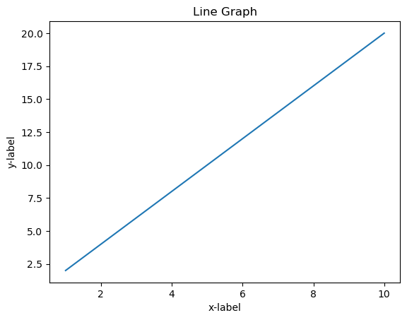

```python
plt.plot(x,y)
plt.title("Line Graph")
plt.xlabel("x-label")
plt.ylabel("y-label")
plt.show()
```

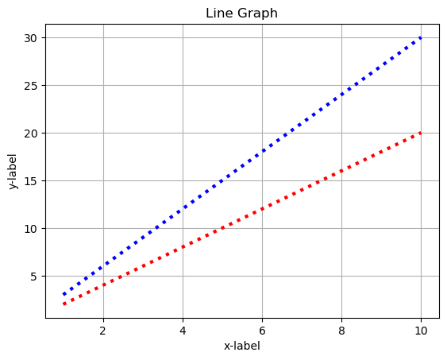

```python
x = np.arange(1,11)
y = 2 * x
y2 = 3 * x
plt.plot(x,y, color='r', linestyle=':', linewidth=3)
plt.plot(x,y2, color='b', linestyle=':', linewidth=3)
plt.title("Line Graph")
plt.xlabel("x-label")
plt.ylabel("y-label")
plt.grid(True)
plt.show()
```

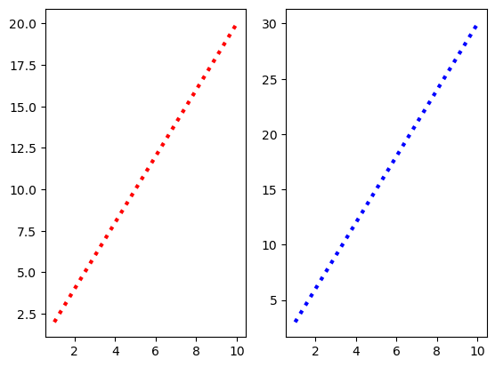

```python
x = np.arange(1,11)
y = 2 * x
y2 = 3 * x

# plt.title("Line Graph")
# plt.xlabel("x-label")
# plt.ylabel("y-label")
# plt.grid(True)

plt.subplot(1,2,1)
plt.plot(x,y, color='r', linestyle=':', linewidth=3)
plt.subplot(1,2,2)
plt.plot(x,y2, color='b', linestyle=':', linewidth=3)

plt.show()
```

## Bar Plot

A bar plot is a type of chart or graph that represents categorical data with rectangular bars. The length of each bar is proportional to the value it represents.

### Key components of a bar plot:

- X-axis: Represents the categories or groups of data.
- Y-axis: Represents the values or frequency of each category.
- Bars: Rectangular shapes whose height or length corresponds to the data value.

## Types of bar plots:

- Vertical bar plot: Bars are oriented vertically.
- Horizontal bar plot: Bars are oriented horizontally.
- Stacked bar plot: Multiple bars are stacked on top of each other to show the composition of a category.
- Grouped bar plot: Bars are grouped together to compare multiple categories.

### When to use a bar plot:

- To compare values across different categories.
- To show the distribution of categorical data.
- To visualize changes in values over time (using grouped or stacked bar plots).

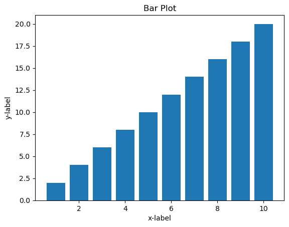

```python
x = np.arange(1,11)
y = 2 * x
plt.bar(x,y)
plt.title("Bar Plot")
plt.xlabel("x-label")
plt.ylabel("y-label")
plt.show()
```

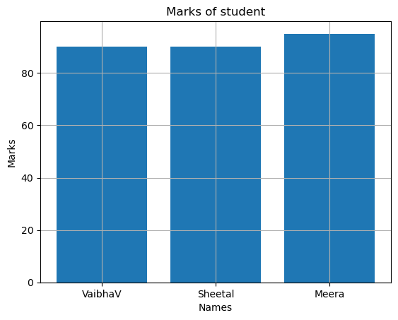

```python
studets= {"VaibhaV": 90, "Sheetal": 90, "Meera": 95}
names = list(studets.keys())
marks = list(studets.values())
plt.bar(names,marks)
plt.title("Marks of student")
plt.xlabel("Names")
plt.ylabel("Marks")
plt.grid(True)
plt.show()
```

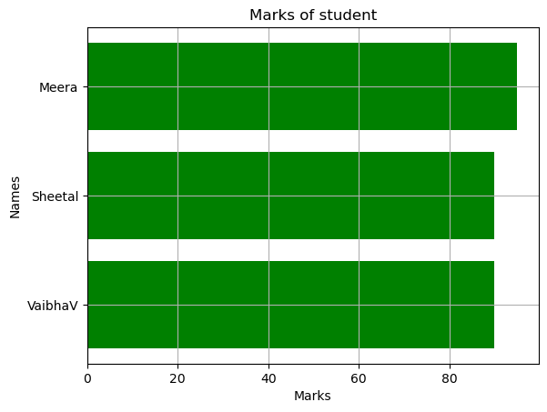

```python
# Horizontal Bar Plot
plt.barh(names,marks, color='g')
plt.title("Marks of student")
plt.xlabel("Marks")
plt.ylabel("Names")
plt.grid(True)
plt.show()
```

## Scatter Plot

A scatter plot is a type of graph that displays the relationship between two numerical variables. Each data point is represented by a dot on the graph, with the position of the dot determined by its values for the two variables.

### Key components of a scatter plot:

- X-axis: Represents one numerical variable.
- Y-axis: Represents the other numerical variable.
- Data points: Represent individual observations, with their position determined by their values on the x and y axes.

### When to use a scatter plot:

- To explore the relationship between two numerical variables.
- To identify patterns or trends in the data.
- To detect outliers or unusual data points.

### Examples of scatter plots:

- Relationship between height and weight.
- Correlation between study hours and exam scores.
- Distribution of house prices based on square footage.

### Advantages of scatter plots:

- Easy to visualize the relationship between two variables.
- Can reveal patterns, trends, and outliers.
- Useful for exploratory data analysis.

```
x: [ 5  4  5  8  2  3 15 19  6 14]
y: [17 16  8  2  9  5 13 16  6 19]
```

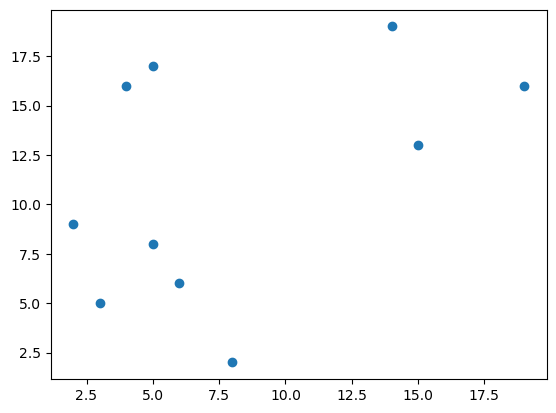

```python
# Scatter plot
x = np.random.randint(1,20,10)
print(f"x: {x}")
y = np.random.randint(1,20,10)
print(f"y: {y}")
plt.scatter(x,y)
plt.show()
```

```
x: [ 4 16 13  6  2 18  8 17  8 10]
y: [16 11 16  6  4 13 16  4 14  1]
```

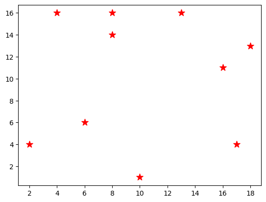

```python
x = np.random.randint(1,20,10)
print(f"x: {x}")
y = np.random.randint(1,20,10)
print(f"y: {y}")
plt.scatter(x,y, color='r', marker='*', s=100)
plt.show()
```

```
x: [ 8  2  4 14  3 16  9 13  2 11]
y: [ 6 14 18 18 19 12 17 12  3  2]
y2: [19 10 15  4  6  9 17 16  2 11]
```

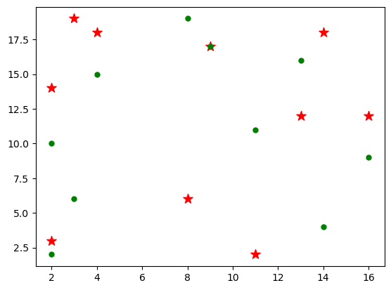

```python
x = np.random.randint(1,20,10)
print(f"x: {x}")
y = np.random.randint(1,20,10)
print(f"y: {y}")
y2 = np.random.randint(1,20,10)
print(f"y2: {y2}")
plt.scatter(x,y, color='r', marker='*', s=100)
plt.scatter(x,y2, color='g', marker='.', s=100)
plt.show()
```

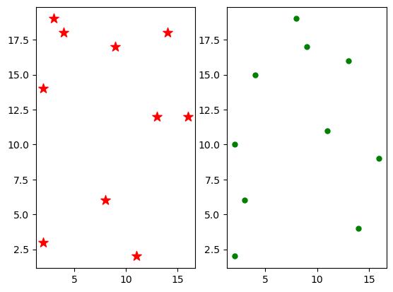

```python
plt.subplot(1,2,1)
plt.scatter(x,y, color='r', marker='*', s=100)
plt.subplot(1,2,2)
plt.scatter(x,y2, color='g', marker='.', s=100)
plt.show()
```

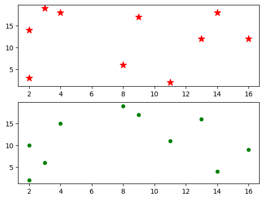

```python
plt.subplot(2,1,1)
plt.scatter(x,y, color='r', marker='*', s=100)
plt.subplot(2,1,2)
plt.scatter(x,y2, color='g', marker='.', s=100)
plt.show()
```

## Histogram

A histogram is a graphical representation of the distribution of numerical data. It's similar to a bar chart, but there are key differences:

- Bars are adjacent: Unlike bar charts, the bars in a histogram touch each other to indicate continuous data.
- Horizontal axis represents intervals: The x-axis shows ranges of values, called bins or class intervals.
- Vertical axis represents frequency: The y-axis shows the number of data points that fall within each bin.

### Key uses of a histogram:

- Understanding data distribution: It helps visualize the shape, center, and spread of data.
- Identifying outliers: Unusual data points can be easily spotted.
- Comparing distributions: Histograms can be used to compare different datasets.

```
x: [ 7  6  8  2  9  3  2  3 10  4  9  2  9  1  3  3  5  2  3  6]
```

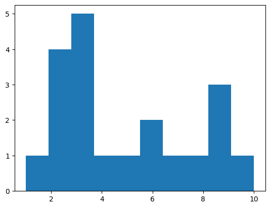

```python
# Histogram

x = np.random.randint(1,11,20)
print(f"x: {x}")
plt.hist(x)
plt.show()
```

```
x: [49 39  5  5 74 35 84 87 63 66 98 96 93 20 23  5 85 96 70 97]
```

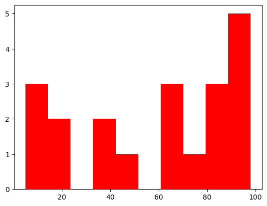

```python
x = np.random.randint(1,100,20)
print(f"x: {x}")
plt.hist(x, color='r', bins=10)
plt.show()
```

```
     sepal_length  sepal_width  petal_length  petal_width    species
145           6.7          3.0           5.2          2.3  virginica
146           6.3          2.5           5.0          1.9  virginica
147           6.5          3.0           5.2          2.0  virginica
148           6.2          3.4           5.4          2.3  virginica
149           5.9          3.0           5.1          1.8  virginica
```

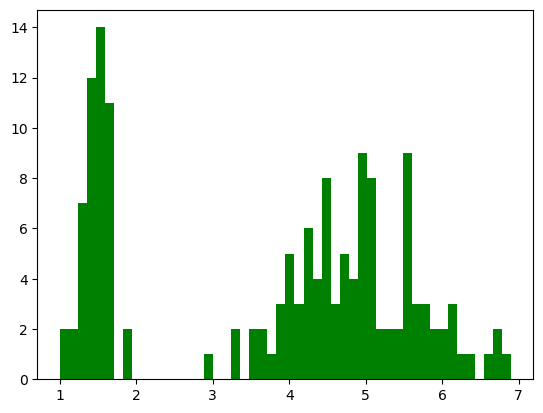

```python
iris= pd.read_csv('data/iris.csv')
print(iris.tail())
x= iris['petal_length']
plt.hist(x, color='g', bins=50)
plt.show()
```

## Box Plot

A box plot (also known as a box-and-whisker plot) is a graphical representation of the distribution of a dataset. It provides a visual summary of five key statistical measures:

- Minimum: The smallest value in the dataset (excluding outliers).
- First quartile (Q1): The value below which 25% of the data lies.
- Median (Q2): The middle value of the dataset.
- Third quartile (Q3): The value below which 75% of the data lies.
- Maximum: The largest value in the dataset (excluding outliers).

### How to interpret a box plot:

- The box: Represents the interquartile range (IQR), which contains the middle 50% of the data.
- The line within the box: Indicates the median.
- The whiskers: Extend from the box to the minimum and maximum values (excluding outliers).
- Outliers: Data points that fall outside the whiskers are often represented as individual points.

### Why use a box plot?

- Quick overview of data: Provides a summary of the distribution at a glance.
- Comparison of groups: Multiple box plots can be used to compare different datasets.
- Identification of outliers: Unusual data points can be easily spotted.

```
x: [21 24 33 49 29 39 35 23 36 48 32 28 43 40 27 29 32 23 46 32]
y: [24 24 27 29 20 25 41 31 30 34 45 39 34 47 24 38 39 34 23 29]
z: [25 27 44 34 58 54 32 12 31 48 23 32 53 68 25 21 49 20 68 40 38 39 55 41
 12 62 50 15 36 26]
```

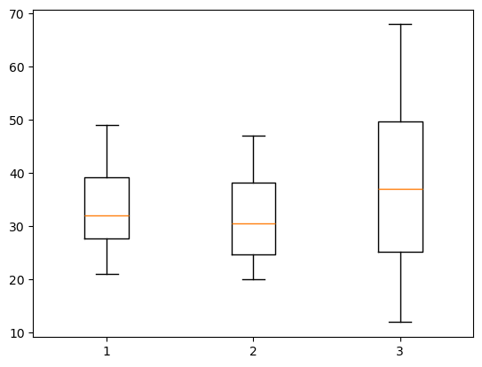

```python
# Box Plot

x= np.random.randint(20,50,20)
y= np.random.randint(20,50,20)
z= np.random.randint(10,70,30)
print(f"x: {x}")
print(f"y: {y}")
print(f"z: {z}")
data= list([x,y,z])
plt.boxplot(data)
plt.show()
```

## Violin Plot

A violin plot is a statistical graphic for comparing probability distributions. It combines elements of a box plot and a kernel density plot.

## Key components:

- Density plot: The shape of the violin represents the probability density of the data.
- Box plot: Typically overlaid on the violin, showing the median, quartiles, and sometimes outliers.

### Advantages of violin plots:

- Shows distribution: Provides a detailed view of the data distribution, including peaks, valleys, and skewness.
- Comparison: Effective for comparing distributions across different groups.
- Outlier detection: Can help identify potential outliers.

## When to use a violin plot:

- When you want to visualize the distribution of numerical data.
- When comparing distributions between multiple groups.
- To complement box plots by providing more detailed information.

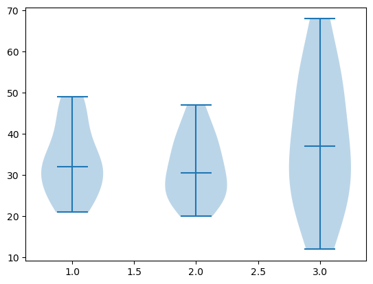

```python
plt.violinplot(data, showmedians=True)
plt.show()
```

## Pie Chart

A pie chart is a circular statistical graphic which is divided into slices to illustrate numerical proportions. In a pie chart, the arc length of each slice is proportional to the quantity it represents. All sectors will sum up to 100%.

### Best used for:

- Showing the composition of a whole.
- Comparing the relative sizes of different categories.

## Donut Chart

A donut chart is similar to a pie chart, but with a hole in the center. This allows for additional information to be displayed in the center, such as totals or averages.

Best used for:

- The same purposes as a pie chart, with the added benefit of displaying additional information in the center.

Important note: While pie and donut charts are visually appealing, they can be difficult to interpret when there are too many categories. In such cases, other chart types like bar charts or column charts might be more effective.

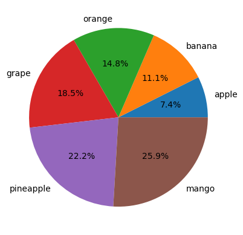

```python
# Pie-Chart
#Dictionary of fruits and their quantity
fruits = {'apple': 10, 'banana': 15, 'orange': 20, 'grape': 25, 'pineapple': 30, 'mango': 35}

# Create a pie chart
plt.pie(fruits.values(), labels=fruits.keys(), autopct='%1.1f%%')
plt.show()
```

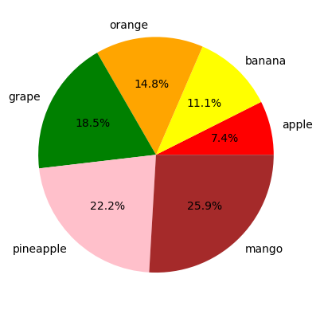

```python
# Pie-Chart
#Dictionary of fruits and their quantity
fruits = {'apple': 10, 'banana': 15, 'orange': 20, 'grape': 25, 'pineapple': 30, 'mango': 35}
# Dictinary of colors for above furits
colors = {'apple': 'red', 'banana': 'yellow', 'orange': 'orange', 'grape': 'green', 'pineapple': 'pink', 'mango': 'brown'}

# Create a pie chart
plt.pie(fruits.values(), labels=fruits.keys(), autopct='%1.1f%%', colors=colors.values())
plt.show()
```

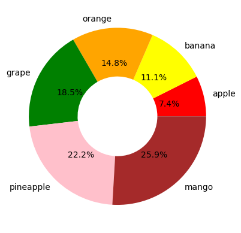

```python
# Donughnut-Chart
#Dictionary of fruits and their quantity
fruits = {'apple': 10, 'banana': 15, 'orange': 20, 'grape': 25, 'pineapple': 30, 'mango': 35}
# Dictinary of colors for above furits
colors = {'apple': 'red', 'banana': 'yellow', 'orange': 'orange', 'grape': 'green', 'pineapple': 'pink', 'mango': 'brown'}

# Create a donughnut chart
plt.pie(fruits.values(), labels=fruits.keys(), autopct='%1.1f%%', colors=colors.values(), wedgeprops={'width': 0.55})
plt.show()
```

## Seaborn

Seaborn is built on top of matplotlib hence , we need to import both seaborn and matplotlib to use seaborn

## Seaborn: A Python Visualization Library

Seaborn is a Python data visualization library built on top of Matplotlib. It provides a high-level interface for creating attractive and informative statistical graphics.

### Key Features:

- High-level interface: Simplifies the process of creating complex visualizations.
- Statistical graphics: Specializes in creating plots that effectively communicate statistical insights.
- Attractive defaults: Offers visually appealing styles and color palettes.
- Integration with Pandas: Works seamlessly with Pandas DataFrames.

### Why use Seaborn?

- Explore data: Quickly visualize relationships and patterns within your dataset.
- Communicate findings: Create visually compelling plots to share insights with others.
- Save time: Benefit from pre-built functions and customization options.

### Common Plot Types:

- Categorical plots: Countplot, barplot, boxplot, violinplot, swarm plot, catplot
- Distribution plots: Distplot, histplot, kdeplot, rugplot
- Relational plots: Scatterplot, lineplot, relplot
- Matrix plots: Heatmap, clustermap, pairplot
- By leveraging Seaborn's capabilities, you can effectively explore and understand your data through visually appealing and informative plots.

```python
import numpy as np
import pandas as pd
import seaborn as sns
from matplotlib import pyplot as plt
```

## Seaborn Lineplot

Seaborn's lineplot function is used to visualize relationships between variables where one of the variables is continuous. It's particularly useful for visualizing trends over time or other continuous variables.

### Key Features and Parameters:

- x and y: Specify the variables for the x and y axes.
- data: The dataset to be used.
- hue: Separates observations into multiple lines based on a categorical variable.
- style: Uses different line styles to distinguish between categories.
- size: Adjusts the thickness of lines based on a numerical variable.
- markers: Adds markers to the line plot.
- ci: Controls the confidence interval around the line.

### Additional Customization:

- Color palettes: Use palette parameter to set custom colors.
- Line styles: Control line styles using style parameter.
- Marker styles: Customize marker appearance with markers parameter.
- Axes labels and title: Add labels and titles using plt.xlabel, plt.ylabel, and plt.title.
- By effectively utilizing Seaborn's lineplot function and its parameters, you can create informative and visually appealing line plots to explore your data.

```
  subject  timepoint event    region    signal
0     s13         18  stim  parietal -0.017552
1      s5         14  stim  parietal -0.080883
2     s12         18  stim  parietal -0.081033
3     s11         18  stim  parietal -0.046134
4     s10         18  stim  parietal -0.037970
```

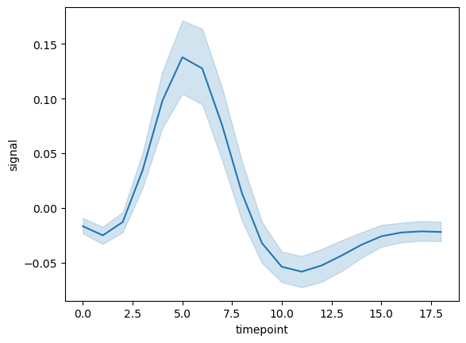

```python
# Line Plot
fmri = sns.load_dataset("fmri")
print(fmri.head())
sns.lineplot(x="timepoint", y="signal", data=fmri)
plt.show()
```

```
  subject  timepoint event    region    signal
0     s13         18  stim  parietal -0.017552
1      s5         14  stim  parietal -0.080883
2     s12         18  stim  parietal -0.081033
3     s11         18  stim  parietal -0.046134
4     s10         18  stim  parietal -0.037970
```

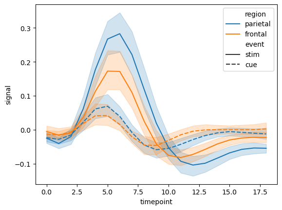

```python
# Line Plot
fmri = sns.load_dataset("fmri")
print(fmri.head())
sns.lineplot(x="timepoint", y="signal", data=fmri , hue="region", style="event")
plt.show()
```

```
  subject  timepoint event    region    signal
0     s13         18  stim  parietal -0.017552
1      s5         14  stim  parietal -0.080883
2     s12         18  stim  parietal -0.081033
3     s11         18  stim  parietal -0.046134
4     s10         18  stim  parietal -0.037970
```

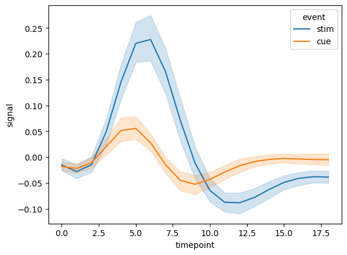

```python
# Line Plot
fmri = sns.load_dataset("fmri")
print(fmri.head())
sns.lineplot(x="timepoint", y="signal", data=fmri , hue="event")
plt.show()
```

```
  subject  timepoint event    region    signal
0     s13         18  stim  parietal -0.017552
1      s5         14  stim  parietal -0.080883
2     s12         18  stim  parietal -0.081033
3     s11         18  stim  parietal -0.046134
4     s10         18  stim  parietal -0.037970
```

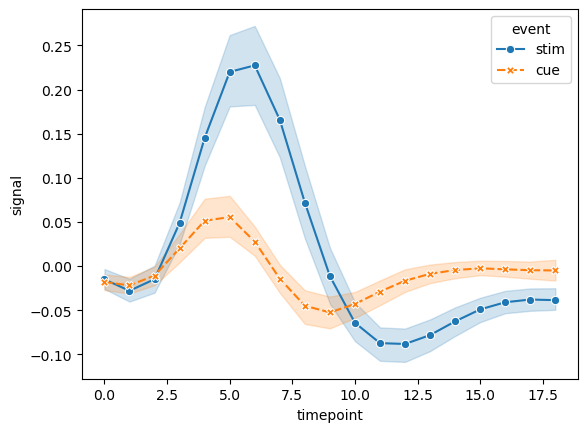

```python
# Line Plot
fmri = sns.load_dataset("fmri")
print(fmri.head())
sns.lineplot(x="timepoint", y="signal", data=fmri , hue="event", style="event", markers=True)
plt.show()
```

## Seaborn Bar Plot

Seaborn's barplot function is used to visualize the relationship between a categorical variable and one or more continuous numerical variables. It represents an estimate of central tendency for a numeric variable with the height of each rectangle and indicates the uncertainty around that estimate using error bars.

## Key Parameters:

- x: The name of the categorical variable to be used on the x-axis.
- y: The name of the numerical variable to be aggregated and visualized.
- data: The dataset to be used.
- hue: Optional categorical variable for creating multiple bars within each category.
- estimator: Function to aggregate the y-value (default is np.mean).
- ci: Confidence interval to display (default is 95%).
- palette: Color palette for the bars.
- errorbar: Type of error bar to display (default is 'ci').

## Additional Customization:

- orient: To create horizontal bar plots.
- saturation: Adjust the color saturation.
- ax: To plot on a specific matplotlib axes.
- Other aesthetic parameters from Matplotlib can be used for further customization.

Seaborn's bar plot is a versatile tool for visualizing categorical data and understanding relationships between categorical and numerical variables. By exploring the different parameters and customization options, you can create informative and visually appealing bar plots.

```
   number                 name  type1   type2  total  hp  attack  defense  \
0       1            Bulbasaur  Grass  Poison    318  45      49       49
1       2              Ivysaur  Grass  Poison    405  60      62       63
2       3             Venusaur  Grass  Poison    525  80      82       83
3       3        Mega Venusaur  Grass  Poison    625  80     100      123
4       3  Gigantamax Venusaur  Grass  Poison    525  80      82       83

   sp_attack  sp_defense  speed  generation  legendary
0         65          65     45           1      False
1         80          80     60           1      False
2        100         100     80           1      False
3        122         120     80           1      False
4        100         100     80           1      False
```

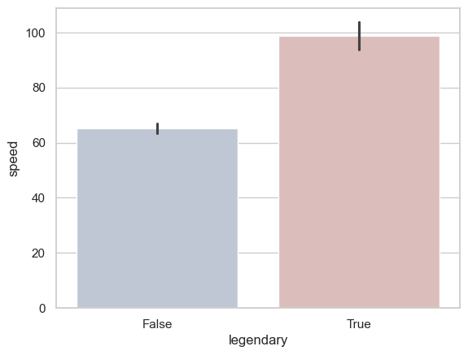

```python
sns.set_theme(style="whitegrid")
pokemon = pd.read_csv('data/pokemon.csv')
print(pokemon.head())
sns.barplot(x="legendary", y="speed", data=pokemon, palette="vlag")
plt.show()
```

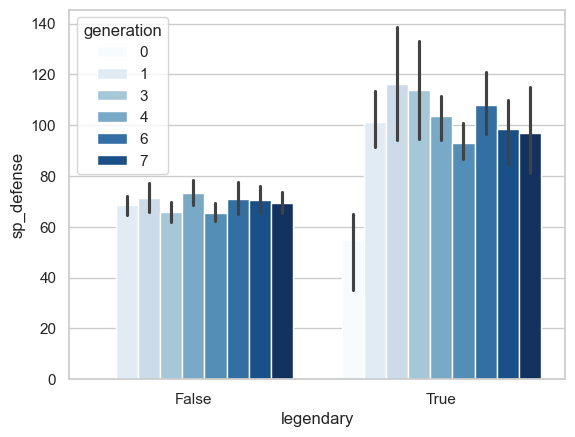

```python
sns.barplot(x="legendary", y="sp_defense",hue="generation", data=pokemon, palette="Blues")
plt.show()
```

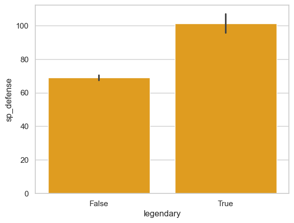

```python
sns.barplot(x="legendary", y="sp_defense", data=pokemon, color="orange")
plt.show()
```

```python
iris =pd.read_csv('data/iris.csv')
iris.head()
```

|  | sepal_length | sepal_width | petal_length | petal_width | species |
| --- | --- | --- | --- | --- | --- |
| 0 | 5.1 | 3.5 | 1.4 | 0.2 | setosa |
| 1 | 4.9 | 3.0 | 1.4 | 0.2 | setosa |
| 2 | 4.7 | 3.2 | 1.3 | 0.2 | setosa |
| 3 | 4.6 | 3.1 | 1.5 | 0.2 | setosa |
| 4 | 5.0 | 3.6 | 1.4 | 0.2 | setosa |

## Seaborn Scatterplot

Seaborn's scatterplot function is used to visualize the relationship between two numerical variables. Each data point is represented by a marker, and the position of the marker on the x and y axes corresponds to the values of the two variables.

### Key Parameters:

- x: The name of the numerical variable to be used on the x-axis.
- y: The name of the numerical variable to be used on the y-axis.
- data: The dataset to be used.
- hue: Optional categorical variable for grouping data points by color.
- style: Optional categorical variable for grouping data points by marker style.
- size: Optional numerical variable for controlling the size of the markers.
- palette: Color palette for the scatter plot.
- alpha: Transparency of the markers.

### Additional Customization:

- markers: Customize the marker style.
- edgecolor: Set the color of the marker edges.
- linewidth: Adjust the width of the marker edges.
- s: Manually set the marker size.

Seaborn's scatterplot is a versatile tool for exploring relationships between numerical variables. By using the various parameters, you can create informative and visually appealing scatter plots to understand your data.

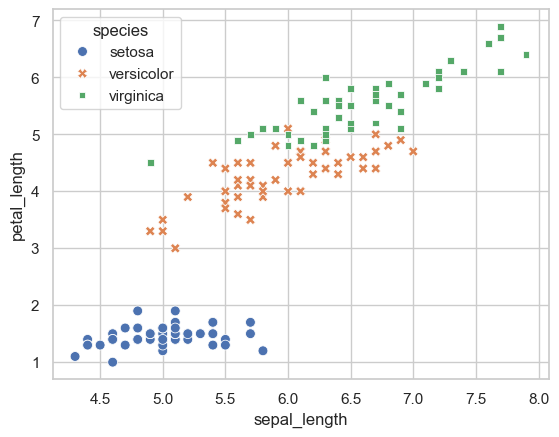

```python
sns.scatterplot(x="sepal_length", y="petal_length",  style="species", data=iris, hue="species", s=50)
plt.show()
```

## Seaborn Histogram

Seaborn's histplot function is used to visualize the distribution of a numerical variable. It counts the number of observations that fall within discrete bins and represents this count with rectangular bars.

## Key Parameters:

- data: The dataset to be used.
- x: The name of the numerical variable to be plotted.
- y: Optional variable for bivariate histograms.
- hue: Optional categorical variable for creating multiple histograms.
- bins: Number of bins for the histogram.
- kde: Whether to plot a kernel density estimate (KDE) curve.
- stat: The statistic to compute in each bin (e.g., 'count', 'density', 'probability').
- common_norm: Whether to normalize histograms when using hue.
- element: The visual representation of the data (e.g., 'bars', 'step', 'poly')